# Assignment 1 -- Insights from Overwatch League

## 76 total marks

```python
# You will need the following packages
import pandas as pd
import matplotlib.pyplot as plt
import seaborn as sns
import numpy as np
```

## Introduction

**Business Context.** You work for Overwatch League, the premier esports league for the game Overwatch. They have collected data about past pro tournaments and would like you to answer some questions about past tournaments. Build visualizations and answer the questions below.

**About Overwatch League.** In the Overwatch League, teams of professional players compete against each other to be the best in the world at playing the team-based first-person shooter game, Overwatch.

Each match consists of two teams of six players each, with each player selecting one of the game's many heroes to play as. The teams are then tasked with completing various objectives, such as escorting a payload across the map or capturing and holding control points.

The team that is able to complete their objectives the quickest or prevent the other team from completing their objectives wins the match.

Matches are typically played in a best-of-three format, meaning that the first team to win two rounds is declared the winner. **Each round is called a "map"**, and the team that wins the most maps wins the match.

The Overwatch League is divided into two seasons per year, with teams from all around the world competing in a variety of different venues. The top teams from each season advance to the playoffs, where they compete for the chance to be crowned the Overwatch League champion. **Each map is one of two types, it is either a control map or an escort map**.

**Business Problem.** Your task is to format the given data and provide visualizations that would answer the specific questions the client has, which are mentioned below.

- **Analytical Context.** You are given a CSV file (stored in the already created `data` folder) containing details about each match like winning team, map type, date of match, tournament title, etc. You will be performing the following tasks on the data:
1. Read, transform, and prepare data for visualization
2. Perform analytics and construct visualizations of the data to identify patterns in the dataset

The client has a specific set of questions they would like to get answers to. You will need to provide visualizations to accompany these.

# Question 1 -- loading in and getting an overview (5 marks)

**1a) (1 mark)** Use the pandas function `read_csv()` to load the file `match_map_stats.csv` as a DataFrame. Name this DataFrame `df`.

```python
df = pd.read_csv("data/match_map_stats.csv")
```

**1b) (1 mark)** Print the first 5 rows of the DataFrame

```python
df.head()
```

|  | round_start_time | round_end_time | stage | match_id | game_number | match_winner | map_winner | map_loser | map_name | map_round | ... | team_one_name | team_two_name | attacker_payload_distance | defender_payload_distance | attacker_time_banked | defender_time_banked | attacker_control_perecent | defender_control_perecent | attacker_round_end_score | defender_round_end_score |
| --- | --- | --- | --- | --- | --- | --- | --- | --- | --- | --- | --- | --- | --- | --- | --- | --- | --- | --- | --- | --- | --- |
| 0 | 01/11/18 00:12 | 01/11/18 00:20 | 2018: Stage 1 | 10223 | 1 | Los Angeles Valiant | Los Angeles Valiant | San Francisco Shock | Dorado | 1 | ... | Los Angeles Valiant | San Francisco Shock | 75.61505 | 0.00000 | 0.000000 | 240.000 | NaN | NaN | 2 | 0 |
| 1 | 01/11/18 00:22 | 01/11/18 00:27 | 2018: Stage 1 | 10223 | 1 | Los Angeles Valiant | Los Angeles Valiant | San Francisco Shock | Dorado | 2 | ... | Los Angeles Valiant | San Francisco Shock | 75.64960 | 75.61505 | 125.750570 | 0.000 | NaN | NaN | 3 | 2 |
| 2 | 01/11/18 00:34 | 01/11/18 00:38 | 2018: Stage 1 | 10223 | 2 | Los Angeles Valiant | Los Angeles Valiant | San Francisco Shock | Temple of Anubis | 1 | ... | Los Angeles Valiant | San Francisco Shock | 0.00000 | 0.00000 | 250.492000 | 240.000 | NaN | NaN | 2 | 0 |
| 3 | 01/11/18 00:40 | 01/11/18 00:44 | 2018: Stage 1 | 10223 | 2 | Los Angeles Valiant | Los Angeles Valiant | San Francisco Shock | Temple of Anubis | 2 | ... | Los Angeles Valiant | San Francisco Shock | 0.00000 | 0.00000 | 225.789030 | 250.492 | NaN | NaN | 2 | 2 |
| 4 | 01/11/18 00:46 | 01/11/18 00:49 | 2018: Stage 1 | 10223 | 2 | Los Angeles Valiant | Los Angeles Valiant | San Francisco Shock | Temple of Anubis | 3 | ... | Los Angeles Valiant | San Francisco Shock | 0.00000 | 0.00000 | 36.396057 | 250.492 | NaN | NaN | 4 | 2 |

5 rows × 25 columns

We have the following columns

- **round_start_time** Stating time of the round
- **round_end_time** Ending time of the round
- **stage** Stage of the competition
- **match_id** Id for the match
- **game_number** Game number in the given match
- **match_winner** Winner of the match
- **map_winner** Winner of the game/map
- **map_loser** Lost of the game/map
- **map_name** Name of map
- **map_round** Round number (each map has several rounds)
- **winning_team_final_map_score** Final score of map winner
- **losing_team_final_map_score** Final score of map loser
- **control_round_name** Name of the round if it was a control type map
- **attacker** Team that was the attacker
- **defender** Team that was the defender
- **team_one_name** Name of first team in match
- **team_two_name** Name of second team in match
- **attacker_payload_distance** Distance the attacker moved the payload on payload maps
- **defender_payload_distance**
- **attacker_time_banked** Attacker time left over
- **defender_time_banked** Defender time left over
- **attacker_control_perecent** Percent objective was charged by the attacker team
- **defender_control_perecent** Percent objective was charged by the defender team
- **attacker_round_end_score** Attacker score at the end of this round
- **defender_round_end_score** Defender score at the end of this round

```python
df.columns
```

```
Index(['round_start_time', 'round_end_time', 'stage', 'match_id',
       'game_number', 'match_winner', 'map_winner', 'map_loser', 'map_name',
       'map_round', 'winning_team_final_map_score',
       'losing_team_final_map_score', 'control_round_name', 'Attacker',
       'Defender', 'team_one_name', 'team_two_name',
       'attacker_payload_distance', 'defender_payload_distance',
       'attacker_time_banked', 'defender_time_banked',
       'attacker_control_perecent', 'defender_control_perecent',
       'attacker_round_end_score', 'defender_round_end_score'],
      dtype='object')
```

**1d) (2 marks)** Answer the following question:

Overwatch is aiming to expand their fanbase through the following advertising campaigns:

- Advertising the most popular teams - *Note:* we can't directly assess from the data which team was most popular
- Promoting a rematch between last years best teams
- Creating an underdog story by highlighting last years worst performing teams
- Which demographics are more likely to buy tickets?

Which of these initiatives could directly benefit from an analysis of the data provided? Check all that apply.

**Note:** You can create check marks by double-clicking this cell and adding an `[x]` in the corresponding lines.

# Question 2 -- Cleaning the data (5 marks)

In this dataset there are two types of maps, escort and control. On control maps, the teams try to control an objective until the meter reaches 100. On escort maps, the attacker tries to escort a payload to the end of the map, while the defender tries to stop it. Control maps can be found in the dataset by rows where the `control_perecent` is not 0 for at least one team. That is, `control_perecent` will be Nan or 0 for both teams when the map is **not** a control map.

### Rules

- If `control_percent` for at least one of the teams > `0` --> **control map**
- If `control_percent` for both teams `= 0` or `NaN` --> **escort map**

```python
# correct typos in column names
df = df.rename(columns = {
    "attacker_control_perecent": "attacker_control_percent",
    "defender_control_perecent": "defender_control_percent"
})
```

- 2a) **(1 marks)** Create a variable for map type called map_type, which has two possible values "control" and "escort".

```python
# 2a
df["map_type"] = np.where(
    (df["attacker_control_percent"] > 0) | (df["defender_control_percent"] > 0),
    "control",
    "escort"
)

df.head(10)
```

|  | round_start_time | round_end_time | stage | match_id | game_number | match_winner | map_winner | map_loser | map_name | map_round | ... | team_two_name | attacker_payload_distance | defender_payload_distance | attacker_time_banked | defender_time_banked | attacker_control_percent | defender_control_percent | attacker_round_end_score | defender_round_end_score | map_type |
| --- | --- | --- | --- | --- | --- | --- | --- | --- | --- | --- | --- | --- | --- | --- | --- | --- | --- | --- | --- | --- | --- |
| 0 | 01/11/18 00:12 | 01/11/18 00:20 | 2018: Stage 1 | 10223 | 1 | Los Angeles Valiant | Los Angeles Valiant | San Francisco Shock | Dorado | 1 | ... | San Francisco Shock | 75.61505 | 0.00000 | 0.000000 | 240.000000 | NaN | NaN | 2 | 0 | escort |
| 1 | 01/11/18 00:22 | 01/11/18 00:27 | 2018: Stage 1 | 10223 | 1 | Los Angeles Valiant | Los Angeles Valiant | San Francisco Shock | Dorado | 2 | ... | San Francisco Shock | 75.64960 | 75.61505 | 125.750570 | 0.000000 | NaN | NaN | 3 | 2 | escort |
| 2 | 01/11/18 00:34 | 01/11/18 00:38 | 2018: Stage 1 | 10223 | 2 | Los Angeles Valiant | Los Angeles Valiant | San Francisco Shock | Temple of Anubis | 1 | ... | San Francisco Shock | 0.00000 | 0.00000 | 250.492000 | 240.000000 | NaN | NaN | 2 | 0 | escort |
| 3 | 01/11/18 00:40 | 01/11/18 00:44 | 2018: Stage 1 | 10223 | 2 | Los Angeles Valiant | Los Angeles Valiant | San Francisco Shock | Temple of Anubis | 2 | ... | San Francisco Shock | 0.00000 | 0.00000 | 225.789030 | 250.492000 | NaN | NaN | 2 | 2 | escort |
| 4 | 01/11/18 00:46 | 01/11/18 00:49 | 2018: Stage 1 | 10223 | 2 | Los Angeles Valiant | Los Angeles Valiant | San Francisco Shock | Temple of Anubis | 3 | ... | San Francisco Shock | 0.00000 | 0.00000 | 36.396057 | 250.492000 | NaN | NaN | 4 | 2 | escort |
| 5 | 01/11/18 00:51 | 01/11/18 00:56 | 2018: Stage 1 | 10223 | 2 | Los Angeles Valiant | Los Angeles Valiant | San Francisco Shock | Temple of Anubis | 4 | ... | San Francisco Shock | 0.00000 | 0.00000 | 0.000000 | 36.396057 | NaN | NaN | 3 | 4 | escort |
| 6 | 01/11/18 01:11 | 01/11/18 01:16 | 2018: Stage 1 | 10223 | 3 | Los Angeles Valiant | Los Angeles Valiant | San Francisco Shock | Ilios | 1 | ... | San Francisco Shock | 0.00000 | 0.00000 | 0.000000 | 0.000000 | 99.0 | 100.0 | 0 | 1 | control |
| 7 | 01/11/18 01:17 | 01/11/18 01:20 | 2018: Stage 1 | 10223 | 3 | Los Angeles Valiant | Los Angeles Valiant | San Francisco Shock | Ilios | 2 | ... | San Francisco Shock | 0.00000 | 0.00000 | 0.000000 | 0.000000 | 100.0 | 0.0 | 1 | 1 | control |
| 8 | 01/11/18 01:20 | 01/11/18 01:25 | 2018: Stage 1 | 10223 | 3 | Los Angeles Valiant | Los Angeles Valiant | San Francisco Shock | Ilios | 3 | ... | San Francisco Shock | 0.00000 | 0.00000 | 0.000000 | 0.000000 | 100.0 | 65.0 | 2 | 1 | control |
| 9 | 01/11/18 01:32 | 01/11/18 01:39 | 2018: Stage 1 | 10223 | 4 | Los Angeles Valiant | Los Angeles Valiant | San Francisco Shock | Numbani | 1 | ... | San Francisco Shock | 75.54951 | 0.00000 | 0.000000 | 0.000000 | NaN | NaN | 1 | 0 | escort |

10 rows × 26 columns

```python
# dataframe of escort
df[np.isnan(df["attacker_control_percent"])] # not a control map
```

|  | round_start_time | round_end_time | stage | match_id | game_number | match_winner | map_winner | map_loser | map_name | map_round | ... | team_two_name | attacker_payload_distance | defender_payload_distance | attacker_time_banked | defender_time_banked | attacker_control_percent | defender_control_percent | attacker_round_end_score | defender_round_end_score | map_type |
| --- | --- | --- | --- | --- | --- | --- | --- | --- | --- | --- | --- | --- | --- | --- | --- | --- | --- | --- | --- | --- | --- |
| 0 | 01/11/18 00:12 | 01/11/18 00:20 | 2018: Stage 1 | 10223 | 1 | Los Angeles Valiant | Los Angeles Valiant | San Francisco Shock | Dorado | 1 | ... | San Francisco Shock | 75.615050 | 0.000000 | 0.000000 | 240.000 | NaN | NaN | 2 | 0 | escort |
| 1 | 01/11/18 00:22 | 01/11/18 00:27 | 2018: Stage 1 | 10223 | 1 | Los Angeles Valiant | Los Angeles Valiant | San Francisco Shock | Dorado | 2 | ... | San Francisco Shock | 75.649600 | 75.615050 | 125.750570 | 0.000 | NaN | NaN | 3 | 2 | escort |
| 2 | 01/11/18 00:34 | 01/11/18 00:38 | 2018: Stage 1 | 10223 | 2 | Los Angeles Valiant | Los Angeles Valiant | San Francisco Shock | Temple of Anubis | 1 | ... | San Francisco Shock | 0.000000 | 0.000000 | 250.492000 | 240.000 | NaN | NaN | 2 | 0 | escort |
| 3 | 01/11/18 00:40 | 01/11/18 00:44 | 2018: Stage 1 | 10223 | 2 | Los Angeles Valiant | Los Angeles Valiant | San Francisco Shock | Temple of Anubis | 2 | ... | San Francisco Shock | 0.000000 | 0.000000 | 225.789030 | 250.492 | NaN | NaN | 2 | 2 | escort |
| 4 | 01/11/18 00:46 | 01/11/18 00:49 | 2018: Stage 1 | 10223 | 2 | Los Angeles Valiant | Los Angeles Valiant | San Francisco Shock | Temple of Anubis | 3 | ... | San Francisco Shock | 0.000000 | 0.000000 | 36.396057 | 250.492 | NaN | NaN | 4 | 2 | escort |
| ... | ... | ... | ... | ... | ... | ... | ... | ... | ... | ... | ... | ... | ... | ... | ... | ... | ... | ... | ... | ... | ... |
| 13676 | 10/16/22 20:54 | 10/16/22 21:02 | 2022: Countdown Cup: Qualifiers | 39329 | 2 | Toronto Defiant | Toronto Defiant | Houston Outlaws | King's Row | 1 | ... | Toronto Defiant | 68.234150 | 0.000000 | 0.000000 | 0.000 | NaN | NaN | 2 | 0 | escort |
| 13677 | 10/16/22 21:04 | 10/16/22 21:12 | 2022: Countdown Cup: Qualifiers | 39329 | 2 | Toronto Defiant | Toronto Defiant | Houston Outlaws | King's Row | 2 | ... | Toronto Defiant | 64.088520 | 68.234150 | 0.000000 | 0.000 | NaN | NaN | 2 | 3 | escort |
| 13678 | 10/16/22 21:20 | 10/16/22 21:25 | 2022: Countdown Cup: Qualifiers | 39329 | 3 | Toronto Defiant | Toronto Defiant | Houston Outlaws | Dorado | 1 | ... | Houston Outlaws | 81.318504 | 0.000000 | 0.000000 | 0.000 | NaN | NaN | 0 | 0 | escort |
| 13679 | 10/16/22 21:26 | 10/16/22 21:29 | 2022: Countdown Cup: Qualifiers | 39329 | 3 | Toronto Defiant | Toronto Defiant | Houston Outlaws | Dorado | 2 | ... | Houston Outlaws | 81.322710 | 81.318504 | 64.900010 | 0.000 | NaN | NaN | 1 | 0 | escort |
| 13680 | 10/16/22 21:37 | 10/16/22 21:48 | 2022: Countdown Cup: Qualifiers | 39329 | 4 | Toronto Defiant | Toronto Defiant | Houston Outlaws | Colosseo | 1 | ... | Toronto Defiant | 65.214136 | 65.642726 | 0.000000 | 0.000 | NaN | NaN | 1 | 0 | escort |

9487 rows × 26 columns

- 2b) **(2 marks)** For rows which correspond to control maps, set the time_banked and payload distance values to `NaN`.

```python
# 2b set time_banked and payload distance to NaN for control maps
df.loc[
    df["map_type"] == "control",
    ["attacker_time_banked", "defender_time_banked", "attacker_payload_distance", "defender_payload_distance"]
] = np.nan
```

- 2c) **(2 marks)** Ensure that `round_start_time` and `round_end_time` time variables are in the `date_time` format and create a variable called `year` which contains the year the match took place

```python
# convert to date_time format
df["round_start_time"] = pd.to_datetime(df["round_start_time"], format = "%m/%d/%y %H:%M")
df["round_end_time"] = pd.to_datetime(df["round_end_time"], format = "%m/%d/%y %H:%M")
```

```python
# testing for NaN values
df[["round_start_time", "round_end_time"]].isna().any()
```

```
round_start_time    False
round_end_time      False
dtype: bool
```

```python
# create a year variable
df["year"] = df["round_start_time"].dt.year

df
```

|  | round_start_time | round_end_time | stage | match_id | game_number | match_winner | map_winner | map_loser | map_name | map_round | ... | attacker_payload_distance | defender_payload_distance | attacker_time_banked | defender_time_banked | attacker_control_percent | defender_control_percent | attacker_round_end_score | defender_round_end_score | map_type | year |
| --- | --- | --- | --- | --- | --- | --- | --- | --- | --- | --- | --- | --- | --- | --- | --- | --- | --- | --- | --- | --- | --- |
| 0 | 2018-01-11 00:12:00 | 2018-01-11 00:20:00 | 2018: Stage 1 | 10223 | 1 | Los Angeles Valiant | Los Angeles Valiant | San Francisco Shock | Dorado | 1 | ... | 75.615050 | 0.000000 | 0.000000 | 240.000 | NaN | NaN | 2 | 0 | escort | 2018 |
| 1 | 2018-01-11 00:22:00 | 2018-01-11 00:27:00 | 2018: Stage 1 | 10223 | 1 | Los Angeles Valiant | Los Angeles Valiant | San Francisco Shock | Dorado | 2 | ... | 75.649600 | 75.615050 | 125.750570 | 0.000 | NaN | NaN | 3 | 2 | escort | 2018 |
| 2 | 2018-01-11 00:34:00 | 2018-01-11 00:38:00 | 2018: Stage 1 | 10223 | 2 | Los Angeles Valiant | Los Angeles Valiant | San Francisco Shock | Temple of Anubis | 1 | ... | 0.000000 | 0.000000 | 250.492000 | 240.000 | NaN | NaN | 2 | 0 | escort | 2018 |
| 3 | 2018-01-11 00:40:00 | 2018-01-11 00:44:00 | 2018: Stage 1 | 10223 | 2 | Los Angeles Valiant | Los Angeles Valiant | San Francisco Shock | Temple of Anubis | 2 | ... | 0.000000 | 0.000000 | 225.789030 | 250.492 | NaN | NaN | 2 | 2 | escort | 2018 |
| 4 | 2018-01-11 00:46:00 | 2018-01-11 00:49:00 | 2018: Stage 1 | 10223 | 2 | Los Angeles Valiant | Los Angeles Valiant | San Francisco Shock | Temple of Anubis | 3 | ... | 0.000000 | 0.000000 | 36.396057 | 250.492 | NaN | NaN | 4 | 2 | escort | 2018 |
| ... | ... | ... | ... | ... | ... | ... | ... | ... | ... | ... | ... | ... | ... | ... | ... | ... | ... | ... | ... | ... | ... |
| 13676 | 2022-10-16 20:54:00 | 2022-10-16 21:02:00 | 2022: Countdown Cup: Qualifiers | 39329 | 2 | Toronto Defiant | Toronto Defiant | Houston Outlaws | King's Row | 1 | ... | 68.234150 | 0.000000 | 0.000000 | 0.000 | NaN | NaN | 2 | 0 | escort | 2022 |
| 13677 | 2022-10-16 21:04:00 | 2022-10-16 21:12:00 | 2022: Countdown Cup: Qualifiers | 39329 | 2 | Toronto Defiant | Toronto Defiant | Houston Outlaws | King's Row | 2 | ... | 64.088520 | 68.234150 | 0.000000 | 0.000 | NaN | NaN | 2 | 3 | escort | 2022 |
| 13678 | 2022-10-16 21:20:00 | 2022-10-16 21:25:00 | 2022: Countdown Cup: Qualifiers | 39329 | 3 | Toronto Defiant | Toronto Defiant | Houston Outlaws | Dorado | 1 | ... | 81.318504 | 0.000000 | 0.000000 | 0.000 | NaN | NaN | 0 | 0 | escort | 2022 |
| 13679 | 2022-10-16 21:26:00 | 2022-10-16 21:29:00 | 2022: Countdown Cup: Qualifiers | 39329 | 3 | Toronto Defiant | Toronto Defiant | Houston Outlaws | Dorado | 2 | ... | 81.322710 | 81.318504 | 64.900010 | 0.000 | NaN | NaN | 1 | 0 | escort | 2022 |
| 13680 | 2022-10-16 21:37:00 | 2022-10-16 21:48:00 | 2022: Countdown Cup: Qualifiers | 39329 | 4 | Toronto Defiant | Toronto Defiant | Houston Outlaws | Colosseo | 1 | ... | 65.214136 | 65.642726 | 0.000000 | 0.000 | NaN | NaN | 1 | 0 | escort | 2022 |

13681 rows × 27 columns

# Question 3 -- Win rates on control maps (14 marks)

- 3a) **(2 marks)** Create and print a sorted list of the unique teams. Store this list in a variable called `teams`.

```python
# get unique teams from team_one_name and team_two_name
team_one_name = df.team_one_name.unique()
team_two_name = df.team_two_name.unique()

# create list from team one names
teams = list(team_one_name)

# for loop to add in unique team names from team_two_name
for team in team_two_name:

    if team not in teams:
        teams.append(team)

# sort teams in ascending order
teams.sort()
teams
```

```
['Atlanta Reign',
 'Boston Uprising',
 'Chengdu Hunters',
 'Dallas Fuel',
 'Florida Mayhem',
 'Guangzhou Charge',
 'Hangzhou Spark',
 'Houston Outlaws',
 'London Spitfire',
 'Los Angeles Gladiators',
 'Los Angeles Valiant',
 'New York Excelsior',
 'Paris Eternal',
 'Philadelphia Fusion',
 'San Francisco Shock',
 'Seoul Dynasty',
 'Shanghai Dragons',
 'Toronto Defiant',
 'Vancouver Titans',
 'Washington Justice']
```

- 3b) **(1 marks)** Create and print a dictionary called `country` with team names as keys and their corresponding country as the entries.

```python
country = {
    "team names": teams,
    "country": ["USA", "USA", "China", "USA", "USA", "China", "China", "USA", "UK", "USA", "USA", "USA", "France", "USA", "USA", "South Korea",
                 "China", "Canada", "Canada", "USA"]
}

print(country)
```

[output not shown]

A team's win rate is the number of games won divided by the total number of games played

- 3c) **(1 marks)** Subset the DataFrame so that it contains only the control maps.

```python
# 3c
df_control_maps = df.loc[df["map_type"] == "control"].reset_index()
df_control_maps.head()
```

|  | index | round_start_time | round_end_time | stage | match_id | game_number | match_winner | map_winner | map_loser | map_name | ... | attacker_payload_distance | defender_payload_distance | attacker_time_banked | defender_time_banked | attacker_control_percent | defender_control_percent | attacker_round_end_score | defender_round_end_score | map_type | year |
| --- | --- | --- | --- | --- | --- | --- | --- | --- | --- | --- | --- | --- | --- | --- | --- | --- | --- | --- | --- | --- | --- |
| 0 | 6 | 2018-01-11 01:11:00 | 2018-01-11 01:16:00 | 2018: Stage 1 | 10223 | 3 | Los Angeles Valiant | Los Angeles Valiant | San Francisco Shock | Ilios | ... | NaN | NaN | NaN | NaN | 99.0 | 100.0 | 0 | 1 | control | 2018 |
| 1 | 7 | 2018-01-11 01:17:00 | 2018-01-11 01:20:00 | 2018: Stage 1 | 10223 | 3 | Los Angeles Valiant | Los Angeles Valiant | San Francisco Shock | Ilios | ... | NaN | NaN | NaN | NaN | 100.0 | 0.0 | 1 | 1 | control | 2018 |
| 2 | 8 | 2018-01-11 01:20:00 | 2018-01-11 01:25:00 | 2018: Stage 1 | 10223 | 3 | Los Angeles Valiant | Los Angeles Valiant | San Francisco Shock | Ilios | ... | NaN | NaN | NaN | NaN | 100.0 | 65.0 | 2 | 1 | control | 2018 |
| 3 | 15 | 2018-01-11 02:52:00 | 2018-01-11 02:58:00 | 2018: Stage 1 | 10224 | 3 | Los Angeles Gladiators | Los Angeles Gladiators | Shanghai Dragons | Ilios | ... | NaN | NaN | NaN | NaN | 99.0 | 100.0 | 0 | 1 | control | 2018 |
| 4 | 16 | 2018-01-11 02:59:00 | 2018-01-11 03:03:00 | 2018: Stage 1 | 10224 | 3 | Los Angeles Gladiators | Los Angeles Gladiators | Shanghai Dragons | Ilios | ... | NaN | NaN | NaN | NaN | 58.0 | 100.0 | 0 | 2 | control | 2018 |

5 rows × 28 columns

- 3d) **(5 marks)** Make a horizontal bar chart displaying the win rate on control maps of each team, order the bar chart from lowest win rate to highest win rate, add a vertical line at 50%. Color the teams by country. **Hint it is useful to use the `sns.barplot` function, set the `dodge` argument as follows:`dodge=False` and make use of the `orient`, `hue` and `hue_order` arguements.**

```python
# win_rate = number of games won / number of games played (use map winner)

# create empty lists
data_win_rate = []

# create DataFrame from country dictionary
win_rate_control = pd.DataFrame.from_dict(country)

for team in teams:

    # count wins for the team
    team_wins = len(df_control_maps[df_control_maps["map_winner"] == team])
    print(f"{team} Wins: {team_wins}")

    # count total games played (both as winner or loser)
    total_games_played = len(df_control_maps[(df_control_maps["map_winner"] == team) | (df_control_maps["map_loser"] == team)])
    print(f"{team} Total Games Played: {total_games_played}")

    # calculate win_rate
    if total_games_played > 0: # avoid division by zero
        win_rate = team_wins / total_games_played
    else:
        win_rate = 0
    print(f"{team} Win Rate: {win_rate}")
    print()

    # append win rate
    data_win_rate.append(win_rate)

# add win rate column to DataFrame
win_rate_control["win rate"] = data_win_rate

win_rate_control
```

```
Atlanta Reign Wins: 216
Atlanta Reign Total Games Played: 388
Atlanta Reign Win Rate: 0.5567010309278351

Boston Uprising Wins: 187
Boston Uprising Total Games Played: 421
Boston Uprising Win Rate: 0.44418052256532065

Chengdu Hunters Wins: 173
Chengdu Hunters Total Games Played: 356
Chengdu Hunters Win Rate: 0.4859550561797753

Dallas Fuel Wins: 251
Dallas Fuel Total Games Played: 477
Dallas Fuel Win Rate: 0.5262054507337526

Florida Mayhem Wins: 171
Florida Mayhem Total Games Played: 439
Florida Mayhem Win Rate: 0.3895216400911162

Guangzhou Charge Wins: 157
Guangzhou Charge Total Games Played: 322
Guangzhou Charge Win Rate: 0.48757763975155277

Hangzhou Spark Wins: 181
Hangzhou Spark Total Games Played: 343
Hangzhou Spark Win Rate: 0.5276967930029155

Houston Outlaws Wins: 218
Houston Outlaws Total Games Played: 446
Houston Outlaws Win Rate: 0.48878923766816146

London Spitfire Wins: 192
London Spitfire Total Games Played: 444
London Spitfire Win Rate: 0.43243243243243246

Los Angeles Gladiators Wins: 280
Los Angeles Gladiators Total Games Played: 493
Los Angeles Gladiators Win Rate: 0.5679513184584178

```

[output cut: 24 more lines]

```
Shanghai Dragons Wins: 265
Shanghai Dragons Total Games Played: 513
Shanghai Dragons Win Rate: 0.5165692007797271

Toronto Defiant Wins: 165
Toronto Defiant Total Games Played: 327
Toronto Defiant Win Rate: 0.5045871559633027

Vancouver Titans Wins: 138
Vancouver Titans Total Games Played: 301
Vancouver Titans Win Rate: 0.4584717607973422

Washington Justice Wins: 132
Washington Justice Total Games Played: 324
Washington Justice Win Rate: 0.4074074074074074
```

|  | team names | country | win rate |
| --- | --- | --- | --- |
| 0 | Atlanta Reign | USA | 0.556701 |
| 1 | Boston Uprising | USA | 0.444181 |
| 2 | Chengdu Hunters | China | 0.485955 |
| 3 | Dallas Fuel | USA | 0.526205 |
| 4 | Florida Mayhem | USA | 0.389522 |
| 5 | Guangzhou Charge | China | 0.487578 |
| 6 | Hangzhou Spark | China | 0.527697 |
| 7 | Houston Outlaws | USA | 0.488789 |
| 8 | London Spitfire | UK | 0.432432 |
| 9 | Los Angeles Gladiators | USA | 0.567951 |
| 10 | Los Angeles Valiant | USA | 0.475638 |
| 11 | New York Excelsior | USA | 0.537975 |
| 12 | Paris Eternal | France | 0.397260 |
| 13 | Philadelphia Fusion | USA | 0.502783 |
| 14 | San Francisco Shock | USA | 0.597806 |
| 15 | Seoul Dynasty | South Korea | 0.575342 |
| 16 | Shanghai Dragons | China | 0.516569 |
| 17 | Toronto Defiant | Canada | 0.504587 |
| 18 | Vancouver Titans | Canada | 0.458472 |
| 19 | Washington Justice | USA | 0.407407 |

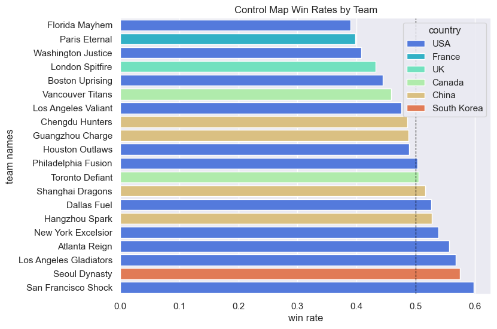

```python
# sort DataFrame by win rate and extract list
win_rate_control_sorted = win_rate_control.sort_values(by = "win rate", ascending = True)

# set plot dimensions
sns.set_theme(font_scale = 1)
plt.figure(figsize = (8, 6))

# creat barplot
sns.barplot(
    data = win_rate_control_sorted, x = "win rate", y = "team names",
    dodge = False, orient = "y",
    hue = "country", palette = "rainbow", saturation = .7
)

# add graph title
plt.title("Control Map Win Rates by Team")

# add vertical line at 0.5
plt.axvline(x = 0.5, color = "black", linestyle = "--", linewidth = .8)
```

- 3e) **(2 marks)** Which teams have a higher than 50% win rate? Do some countries produce better teams than others?

```python
# new DataFrame with teams that have a higher than 50% win rate
win_rate_higher = win_rate_control.loc[win_rate_control["win rate"] > 0.5]
win_rate_higher
```

|  | team names | country | win rate |
| --- | --- | --- | --- |
| 0 | Atlanta Reign | USA | 0.556701 |
| 3 | Dallas Fuel | USA | 0.526205 |
| 6 | Hangzhou Spark | China | 0.527697 |
| 9 | Los Angeles Gladiators | USA | 0.567951 |
| 11 | New York Excelsior | USA | 0.537975 |
| 13 | Philadelphia Fusion | USA | 0.502783 |
| 14 | San Francisco Shock | USA | 0.597806 |
| 15 | Seoul Dynasty | South Korea | 0.575342 |
| 16 | Shanghai Dragons | China | 0.516569 |
| 17 | Toronto Defiant | Canada | 0.504587 |

```python
# tally of country win rates higher than 50%
win_rate_higher["country"].value_counts()
```

```
country
USA            6
China          2
South Korea    1
Canada         1
Name: count, dtype: int64
```

The following teams have a higher than 50% win rate: **Atlanta Reign, Dallas Fuel, Hangzhou Spark, Los Angeles Gladiators, New York Excelsior, Philadelphia Fusion, San Francisco Shock, Seoul Dynasty, Shanghai Dragons, Toronto Defiant**. USA and China seem to produce better teams than others with 6 and 2 respectively having win rates higher than 50%$.

- 3f) **(3 marks)** Make the same plot for each year - are the yearly plots similar to the overall plot?

```python
# create an empty list to store results
win_rate_yearly_data = []

# convert country dictionary into a lookup dictionary
country_lookup = dict(zip(country["team names"], country["country"]))

# iterate through each year in the control maps DataFrame
for year in df_control_maps["year"].unique():

    # filter the DataFrame for the current year
    yearly_data = df_control_maps[df_control_maps["year"] == year]

    # iterate through each team in the teams list
    for team in teams:

        # find country name based on lookup dictionary
        country_name = country_lookup.get(team)

        # count total wins in a given year
        team_wins_yearly = len(yearly_data[yearly_data["map_winner"] == team])

        # count total games played (both as winner or loser) in a given year
        total_games_played_yearly = len(yearly_data[(yearly_data["map_winner"] == team) | (yearly_data["map_loser"] == team)])

        # calculate win_rate
        if total_games_played_yearly > 0: # avoid division by zero
            win_rate_yearly = team_wins_yearly / total_games_played_yearly
        else:
            win_rate_yearly = 0

        # append results in a dictionary
        win_rate_yearly_data.append({
            "year": year,
            "team": team,
            "country": country_name,
            "win rate yearly": win_rate_yearly
        })

# create DataFrame
win_rate_control_by_year = pd.DataFrame(win_rate_yearly_data)
win_rate_control_by_year
```

|  | year | team | country | win rate yearly |
| --- | --- | --- | --- | --- |
| 0 | 2018 | Atlanta Reign | USA | 0.000000 |
| 1 | 2018 | Boston Uprising | USA | 0.609929 |
| 2 | 2018 | Chengdu Hunters | China | 0.000000 |
| 3 | 2018 | Dallas Fuel | USA | 0.354545 |
| 4 | 2018 | Florida Mayhem | USA | 0.278261 |
| ... | ... | ... | ... | ... |
| 95 | 2022 | Seoul Dynasty | South Korea | 0.676768 |
| 96 | 2022 | Shanghai Dragons | China | 0.510204 |
| 97 | 2022 | Toronto Defiant | Canada | 0.536842 |
| 98 | 2022 | Vancouver Titans | Canada | 0.309859 |
| 99 | 2022 | Washington Justice | USA | 0.365854 |

100 rows × 4 columns

```python
# sort DataFrame by year and win rate
win_rate_control_by_year_sorted = win_rate_control_by_year.sort_values(by =["year", "win rate yearly"], ascending = True)
win_rate_control_by_year_sorted.head(20)
```

|  | year | team | country | win rate yearly |
| --- | --- | --- | --- | --- |
| 0 | 2018 | Atlanta Reign | USA | 0.000000 |
| 2 | 2018 | Chengdu Hunters | China | 0.000000 |
| 5 | 2018 | Guangzhou Charge | China | 0.000000 |
| 6 | 2018 | Hangzhou Spark | China | 0.000000 |
| 12 | 2018 | Paris Eternal | France | 0.000000 |
| 17 | 2018 | Toronto Defiant | Canada | 0.000000 |
| 18 | 2018 | Vancouver Titans | Canada | 0.000000 |
| 19 | 2018 | Washington Justice | USA | 0.000000 |
| 16 | 2018 | Shanghai Dragons | China | 0.076923 |
| 4 | 2018 | Florida Mayhem | USA | 0.278261 |
| 3 | 2018 | Dallas Fuel | USA | 0.354545 |
| 14 | 2018 | San Francisco Shock | USA | 0.482143 |
| 7 | 2018 | Houston Outlaws | USA | 0.488722 |
| 8 | 2018 | London Spitfire | UK | 0.510345 |
| 15 | 2018 | Seoul Dynasty | South Korea | 0.528926 |
| 13 | 2018 | Philadelphia Fusion | USA | 0.542484 |
| 1 | 2018 | Boston Uprising | USA | 0.609929 |
| 10 | 2018 | Los Angeles Valiant | USA | 0.634328 |
| 9 | 2018 | Los Angeles Gladiators | USA | 0.639706 |
| 11 | 2018 | New York Excelsior | USA | 0.671233 |

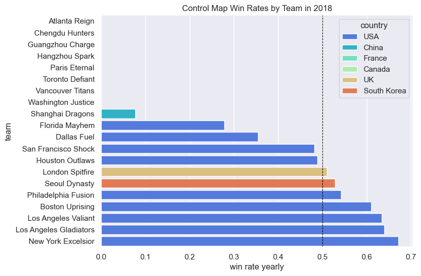

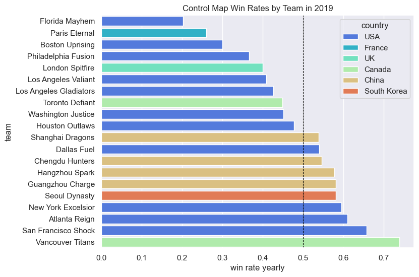

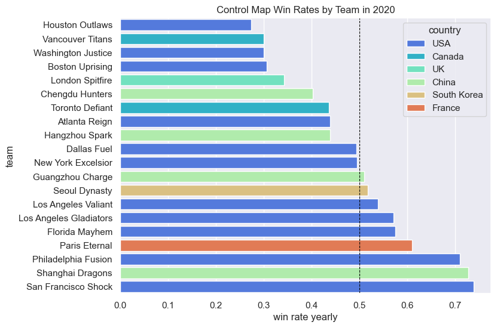

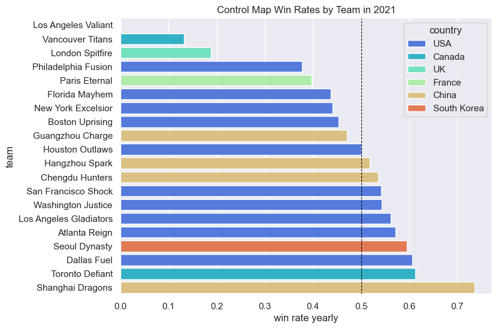

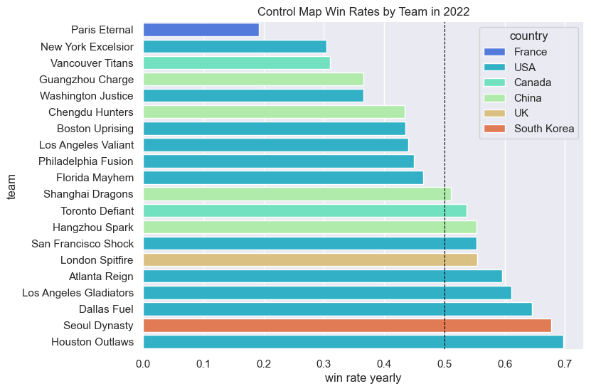

```python
# iterate through each unique year in the sorted DataFrame
for year in win_rate_control_by_year_sorted["year"].unique():

    # set plot dimensions
    sns.set_theme(font_scale = 1)
    plt.figure(figsize = (8, 6))

    # create barplot
    sns.barplot(
        data = win_rate_control_by_year_sorted[win_rate_control_by_year_sorted["year"] == year], x = "win rate yearly", y = "team",
        dodge = False, orient = "y",
        hue = "country", palette = "rainbow", saturation = .7
        )

    # add graph title
    plt.title(f"Control Map Win Rates by Team in {year}")

    # add vertical line at 0.5
    plt.axvline(x = 0.5, color = "black", linestyle = "--", linewidth = .8)
```

# Question 4 -- Win rates over time (17 marks)

- 4a) **(3 marks)** Make a line of the Shanghai Dragons' win rate on control maps over time.

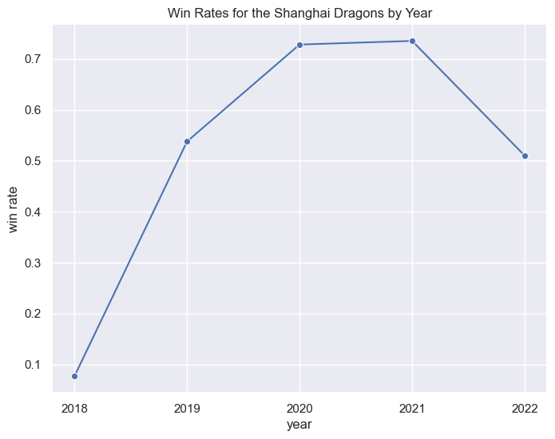

```python
# extract win rate data for Shanghai Dragons
shanghai_dragons_win = win_rate_control_by_year_sorted.loc[win_rate_control_by_year_sorted["team"] == "Shanghai Dragons"]

# set plot dimensions
plt.figure(figsize = (8, 6))

# plot data on a line graph
sns.lineplot(
            data = shanghai_dragons_win,
            x = "year",
            y = "win rate yearly",
            marker = "o"
            )

# specify positions of ticks on x-axis
plt.xticks([2018, 2019, 2020, 2021, 2022])

# add title for graph and axis
plt.title("Win Rates for the Shanghai Dragons by Year")
plt.ylabel("win rate")
```

- 4b) **(1 marks)** How would describe the Shanghai Dragons' win rate on control maps over time?

The Shanghai Dragons' win rate on control maps increased from 2018 to 2021, peaking around 0.75. Between 2020 to 2021, their win rate was relatively stable, but decreased to around 0.5 from 2021 to 2022. Their performance improved from 2018 to 2021 but declined in the most recent year.

- 4c) **(3 marks)** For each team who had a win rate on control maps in the top 5 in 2022, plot their win rates on control maps over time.

```python
# identify top 5 teams in 2022 based on their win rate
win_rate_control_by_year_sorted[win_rate_control_by_year_sorted["year"] == 2022].tail(5)
```

|  | year | team | country | win rate yearly |
| --- | --- | --- | --- | --- |
| 80 | 2022 | Atlanta Reign | USA | 0.595745 |
| 89 | 2022 | Los Angeles Gladiators | USA | 0.611111 |
| 83 | 2022 | Dallas Fuel | USA | 0.645161 |
| 95 | 2022 | Seoul Dynasty | South Korea | 0.676768 |
| 87 | 2022 | Houston Outlaws | USA | 0.696629 |

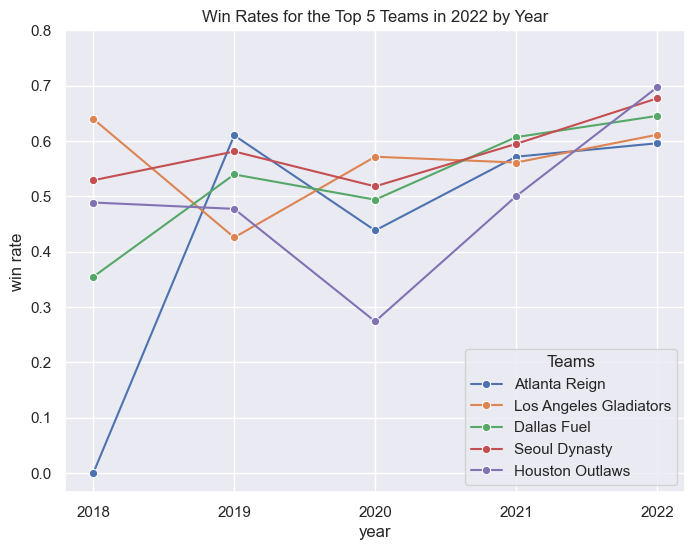

```python
# on a single graph
top_teams = ["Atlanta Reign", "Los Angeles Gladiators", "Dallas Fuel", "Seoul Dynasty", "Houston Outlaws"]

# set plot dimensions
plt.figure(figsize = (8, 6))

for team in top_teams:

    # extract win rate data for team
    top_team = win_rate_control_by_year_sorted.loc[win_rate_control_by_year_sorted["team"] == team]

    # plot data on a line graph
    sns.lineplot(
                data = top_team,
                x = "year",
                y = "win rate yearly",
                marker = "o",
                label = team
    )

    # specify positions of ticks on x-axis
    plt.xticks([2018, 2019, 2020, 2021, 2022])
    plt.yticks([0, 0.1, 0.2, 0.3, 0.4, 0.5, 0.6, 0.7, 0.8])

    # add title for graph and axis
    plt.title("Win Rates for the Top 5 Teams in 2022 by Year")
    plt.ylabel("win rate")

    # add a legend
    plt.legend(title = "Teams", loc = "lower right")
```

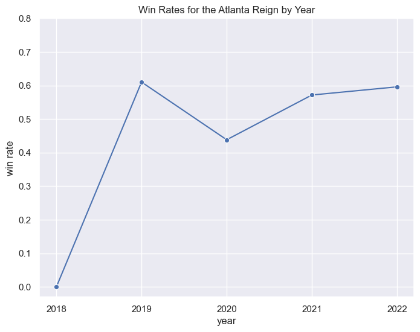

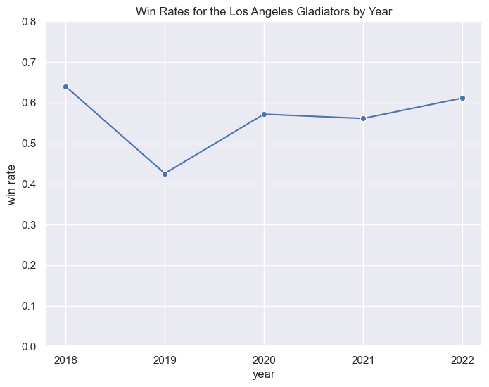

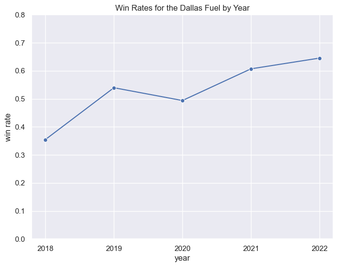

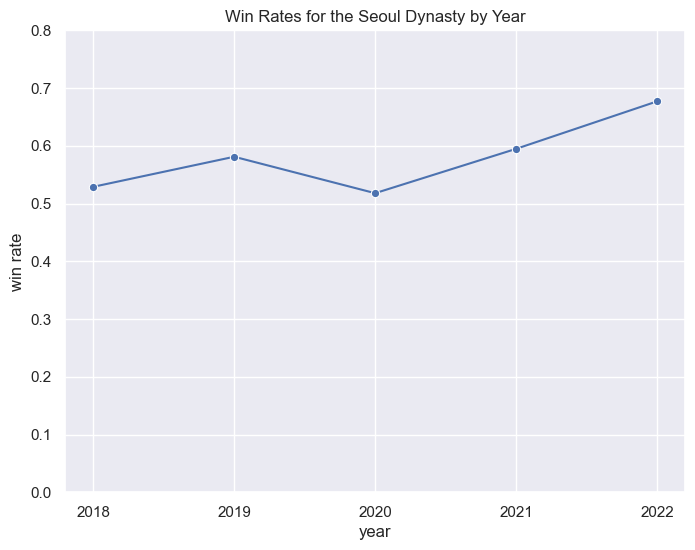

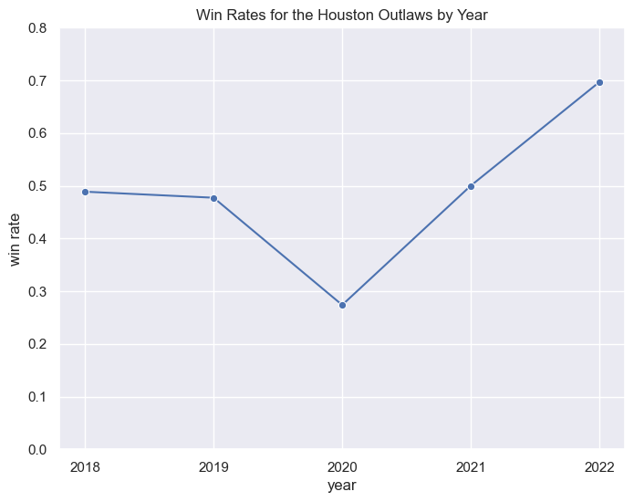

```python
# on separate graphs
top_teams = ["Atlanta Reign", "Los Angeles Gladiators", "Dallas Fuel", "Seoul Dynasty", "Houston Outlaws"]

for team in top_teams:

    # extract win rate data for team
    top_team = win_rate_control_by_year_sorted.loc[win_rate_control_by_year_sorted["team"] == team]

    # set plot dimensions
    plt.figure(figsize = (8, 6))

    # plot data on a line graph
    sns.lineplot(
                data = top_team,
                x = "year",
                y = "win rate yearly",
                marker = "o"
                )

    # specify positions of ticks on x-axis
    plt.xticks([2018, 2019, 2020, 2021, 2022])
    plt.yticks([0, 0.1, 0.2, 0.3, 0.4, 0.5, 0.6, 0.7, 0.8])

    # add title for graph and axis
    plt.title(f"Win Rates for the {team} by Year")
    plt.ylabel("win rate")
```

- 4d) **(2 marks)** Make two observations about these plots.

**Atlanta Reign's** performance improved drastically from 2018 to 2019 (significant increase in win rate from 0 to around 0.6) and peaked in 2019 before declining and then improving again.

- 4e) **(5 marks)** Instead of control maps, make a bar chart of the teams' win rates on the escort maps in 2022, i.e., consider only escort maps which occured in 2022 when computing this win rate.Make the same chart without subsetting to 2022, i.e., compute the escort map win rate for each team using maps which took place in any year. For example, the win rate chart on escort maps for 2022 should look like the following:

[figure not shown]

  Note that the vertical line at 50 is useful but not necessary.

```python
# check to see how many escort map values exist
df["map_type"].value_counts()
```

```
map_type
escort     9487
control    4194
Name: count, dtype: int64
```

```python
# subsetting escort maps
df_escort_maps = df.loc[df["map_type"] == "escort"].reset_index()
df_escort_maps

# create an empty list to store results
data_win_rate_escort = []

# create DataFrame from country dictionary
win_rate_escort_df = pd.DataFrame.from_dict(country)

for team in teams:

    # count wins for the team
    team_wins_escort = len(df_escort_maps[df_escort_maps["map_winner"] == team])

    # count total games played (both as winner or loser)
    total_games_played_escort = len(df_escort_maps[(df_escort_maps["map_winner"] == team) | (df_escort_maps["map_loser"] == team)])

    # calculate win_rate
    if total_games_played_escort > 0: # avoid division by zero
        win_rate_escort = team_wins_escort / total_games_played_escort
    else:
        win_rate_escort = 0

    # append win rate
    data_win_rate_escort.append(win_rate_escort)

# add win rate column to DataFrame
win_rate_escort_df["win rate"] = data_win_rate_escort

# sort DataFrame by win rate
win_rate_escort_sorted = win_rate_escort_df.sort_values(by ="win rate", ascending = True)
win_rate_escort_sorted.head(20)
```

|  | team names | country | win rate |
| --- | --- | --- | --- |
| 17 | Toronto Defiant | Canada | 0.384956 |
| 1 | Boston Uprising | USA | 0.401070 |
| 4 | Florida Mayhem | USA | 0.425871 |
| 5 | Guangzhou Charge | China | 0.436019 |
| 19 | Washington Justice | USA | 0.436282 |
| 10 | Los Angeles Valiant | USA | 0.443956 |
| 2 | Chengdu Hunters | China | 0.446259 |
| 12 | Paris Eternal | France | 0.447605 |
| 3 | Dallas Fuel | USA | 0.473070 |
| 7 | Houston Outlaws | USA | 0.476987 |
| 6 | Hangzhou Spark | China | 0.481066 |
| 18 | Vancouver Titans | Canada | 0.491279 |
| 16 | Shanghai Dragons | China | 0.511545 |
| 8 | London Spitfire | UK | 0.512927 |
| 0 | Atlanta Reign | USA | 0.539773 |
| 15 | Seoul Dynasty | South Korea | 0.551078 |
| 13 | Philadelphia Fusion | USA | 0.558694 |
| 9 | Los Angeles Gladiators | USA | 0.564576 |
| 11 | New York Excelsior | USA | 0.576628 |
| 14 | San Francisco Shock | USA | 0.655672 |

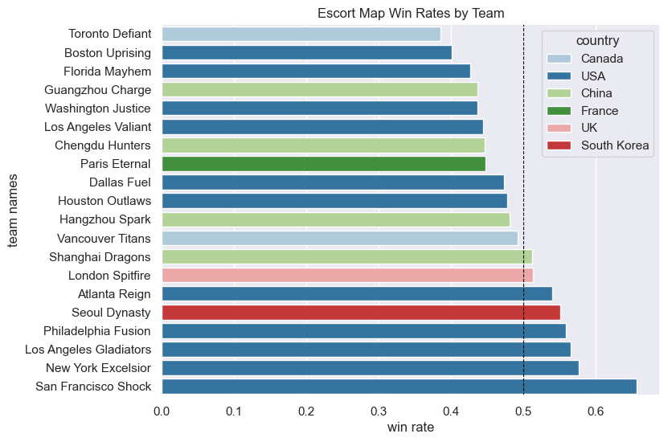

```python
# set plot dimensions
sns.set_theme(font_scale = 1)
plt.figure(figsize = (8, 6))

# creat barplot
sns.barplot(
    data = win_rate_escort_sorted, x = "win rate", y = "team names",
    dodge = False, orient = "y",
    hue = "country", palette = "Paired", saturation = .7
)

# add graph title
plt.title("Escort Map Win Rates by Team")

# add vertical line at 0.5
plt.axvline(x = 0.5, color = "black", linestyle = "--", linewidth = .8)
```

```python
# subset 2022
df_escort_maps_recent = df_escort_maps.loc[df_escort_maps["year"] == 2022].reset_index()
df_escort_maps_recent

# create an empty list to store results
data_win_rate_escort_recent = []

for team in teams:

    # count wins for the team
    team_wins_escort_recent = len(df_escort_maps_recent[df_escort_maps_recent["map_winner"] == team])

    # count total games played (both as winner or loser)
    total_games_played_escort_recent = len(df_escort_maps_recent[(df_escort_maps_recent["map_winner"] == team) | (df_escort_maps_recent["map_loser"] == team)])

    # calculate win_rate
    if total_games_played_escort_recent > 0: # avoid division by zero
        win_rate_escort_recent = team_wins_escort_recent / total_games_played_escort_recent
    else:
        win_rate_escort_recent = 0

    # append win rate
    data_win_rate_escort_recent.append(win_rate_escort_recent)

# create a new DataFram for 2022 with relevant columns
win_rate_escort_df_recent = win_rate_escort_df[["team names", "country"]].copy()
win_rate_escort_df_recent["win rate"] = data_win_rate_escort_recent

# sort DataFrame by win rate
win_rate_escort_sorted_recent = win_rate_escort_df_recent.sort_values(by ="win rate", ascending = True)
win_rate_escort_sorted_recent.head(20)
```

|  | team names | country | win rate |
| --- | --- | --- | --- |
| 12 | Paris Eternal | France | 0.168067 |
| 18 | Vancouver Titans | Canada | 0.256000 |
| 5 | Guangzhou Charge | China | 0.328358 |
| 10 | Los Angeles Valiant | USA | 0.336000 |
| 11 | New York Excelsior | USA | 0.343750 |
| 2 | Chengdu Hunters | China | 0.414286 |
| 1 | Boston Uprising | USA | 0.428571 |
| 17 | Toronto Defiant | Canada | 0.431953 |
| 7 | Houston Outlaws | USA | 0.470270 |
| 4 | Florida Mayhem | USA | 0.497297 |
| 13 | Philadelphia Fusion | USA | 0.497354 |
| 6 | Hangzhou Spark | China | 0.503226 |
| 8 | London Spitfire | UK | 0.525000 |
| 19 | Washington Justice | USA | 0.535032 |
| 0 | Atlanta Reign | USA | 0.555556 |
| 14 | San Francisco Shock | USA | 0.617347 |
| 3 | Dallas Fuel | USA | 0.655914 |
| 16 | Shanghai Dragons | China | 0.666667 |
| 15 | Seoul Dynasty | South Korea | 0.670588 |
| 9 | Los Angeles Gladiators | USA | 0.741758 |

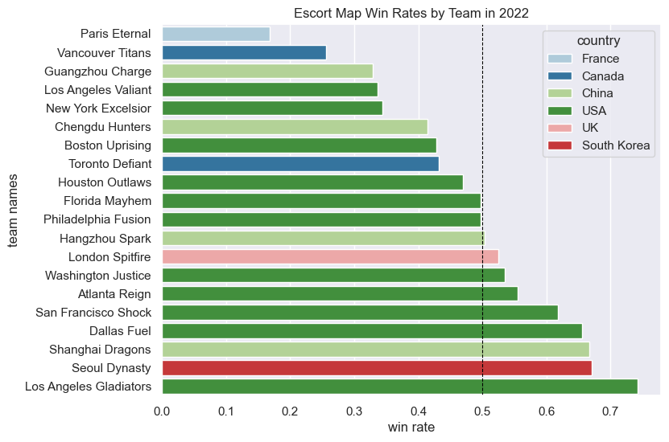

```python
# set plot dimensions
sns.set_theme(font_scale = 1)
plt.figure(figsize = (8, 6))

# creat barplot
sns.barplot(
    data = win_rate_escort_sorted_recent, x = "win rate", y = "team names",
    dodge = False, orient = "y",
    hue = "country", palette = "Paired", saturation = .7
)

# add graph title
plt.title("Escort Map Win Rates by Team in 2022")

# add vertical line at 0.5
plt.axvline(x = 0.5, color = "black", linestyle = "--", linewidth = .8)
```

# Question 5 -- What map should Toronto work on improving? (18 marks)

Suppose you have been contracted as an analyst for the Toronto Defiant team.

- 5a) **(5 marks)** There are different types of control maps, which can be found in the `control_round_name` column. Make a bar chart of Toronto's win rate on each individual control map (can be found in `control_round_name`) for 2022 and all time. For example, your plot might look like:

[figure not shown]

```python
control_round_names = list(df["control_round_name"].dropna().unique())
control_round_names
```

```
['Lighthouse',
 'Ruins',
 'Well',
 'University',
 'Gardens',
 'City Center',
 'Control Center',
 'Night Market',
 'Garden',
 'Shrine',
 'Sanctum',
 'Village',
 'MEKA Base',
 'Downtown',
 'Sanctuary']
```

```python
df_control_maps
```

|  | index | round_start_time | round_end_time | stage | match_id | game_number | match_winner | map_winner | map_loser | map_name | ... | attacker_payload_distance | defender_payload_distance | attacker_time_banked | defender_time_banked | attacker_control_percent | defender_control_percent | attacker_round_end_score | defender_round_end_score | map_type | year |
| --- | --- | --- | --- | --- | --- | --- | --- | --- | --- | --- | --- | --- | --- | --- | --- | --- | --- | --- | --- | --- | --- |
| 0 | 6 | 2018-01-11 01:11:00 | 2018-01-11 01:16:00 | 2018: Stage 1 | 10223 | 3 | Los Angeles Valiant | Los Angeles Valiant | San Francisco Shock | Ilios | ... | NaN | NaN | NaN | NaN | 99.0 | 100.0 | 0 | 1 | control | 2018 |
| 1 | 7 | 2018-01-11 01:17:00 | 2018-01-11 01:20:00 | 2018: Stage 1 | 10223 | 3 | Los Angeles Valiant | Los Angeles Valiant | San Francisco Shock | Ilios | ... | NaN | NaN | NaN | NaN | 100.0 | 0.0 | 1 | 1 | control | 2018 |
| 2 | 8 | 2018-01-11 01:20:00 | 2018-01-11 01:25:00 | 2018: Stage 1 | 10223 | 3 | Los Angeles Valiant | Los Angeles Valiant | San Francisco Shock | Ilios | ... | NaN | NaN | NaN | NaN | 100.0 | 65.0 | 2 | 1 | control | 2018 |
| 3 | 15 | 2018-01-11 02:52:00 | 2018-01-11 02:58:00 | 2018: Stage 1 | 10224 | 3 | Los Angeles Gladiators | Los Angeles Gladiators | Shanghai Dragons | Ilios | ... | NaN | NaN | NaN | NaN | 99.0 | 100.0 | 0 | 1 | control | 2018 |
| 4 | 16 | 2018-01-11 02:59:00 | 2018-01-11 03:03:00 | 2018: Stage 1 | 10224 | 3 | Los Angeles Gladiators | Los Angeles Gladiators | Shanghai Dragons | Ilios | ... | NaN | NaN | NaN | NaN | 58.0 | 100.0 | 0 | 2 | control | 2018 |
| ... | ... | ... | ... | ... | ... | ... | ... | ... | ... | ... | ... | ... | ... | ... | ... | ... | ... | ... | ... | ... | ... |
| 4189 | 13661 | 2022-10-15 22:55:00 | 2022-10-15 23:00:00 | 2022: Countdown Cup: Qualifiers | 39327 | 1 | Florida Mayhem | Houston Outlaws | Florida Mayhem | Nepal | ... | NaN | NaN | NaN | NaN | 67.0 | 100.0 | 1 | 2 | control | 2022 |
| 4190 | 13667 | 2022-10-16 19:08:00 | 2022-10-16 19:12:00 | 2022: Countdown Cup: Qualifiers | 39328 | 1 | Boston Uprising | Paris Eternal | Boston Uprising | Busan | ... | NaN | NaN | NaN | NaN | 46.0 | 100.0 | 0 | 1 | control | 2022 |
| 4191 | 13668 | 2022-10-16 19:13:00 | 2022-10-16 19:17:00 | 2022: Countdown Cup: Qualifiers | 39328 | 1 | Boston Uprising | Paris Eternal | Boston Uprising | Busan | ... | NaN | NaN | NaN | NaN | 77.0 | 100.0 | 0 | 2 | control | 2022 |
| 4192 | 13674 | 2022-10-16 20:37:00 | 2022-10-16 20:42:00 | 2022: Countdown Cup: Qualifiers | 39329 | 1 | Toronto Defiant | Houston Outlaws | Toronto Defiant | Ilios | ... | NaN | NaN | NaN | NaN | 100.0 | 76.0 | 1 | 0 | control | 2022 |
| 4193 | 13675 | 2022-10-16 20:42:00 | 2022-10-16 20:47:00 | 2022: Countdown Cup: Qualifiers | 39329 | 1 | Toronto Defiant | Houston Outlaws | Toronto Defiant | Ilios | ... | NaN | NaN | NaN | NaN | 100.0 | 70.0 | 2 | 0 | control | 2022 |

4194 rows × 28 columns

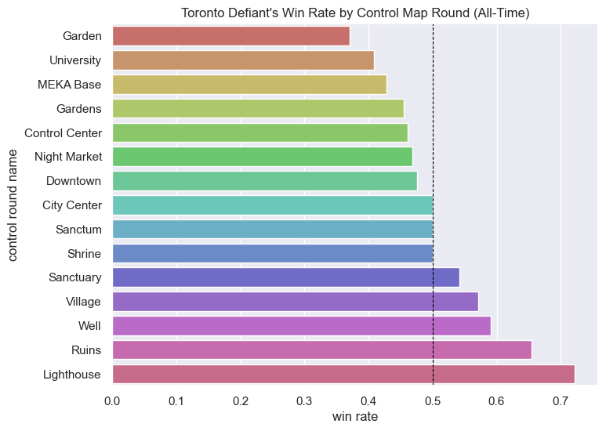

```python
# subset of control map df - df_control_maps

# subset Toronto team and relevant columns
df_control_toronto = df_control_maps[(df_control_maps["map_winner"] == "Toronto Defiant") | (df_control_maps["map_loser"] == "Toronto Defiant")]
df_control_toronto = df_control_toronto[["match_winner", "map_winner", "map_loser", "control_round_name", "year"]]

# create an empty list to store results
win_rates_toronto = df_control_toronto.groupby("control_round_name").apply(
    lambda x: (x["map_winner"] == "Toronto Defiant").sum() / len(x)
).reset_index(name="win_rate")

# sort values in DataFrame
win_rates_toronto = win_rates_toronto.sort_values(by = "win_rate", ascending = True)

# set plot dimensions
sns.set_theme(font_scale = 1)
plt.figure(figsize = (8, 6))

# creat barplot
sns.barplot(
    data = win_rates_toronto, x = "win_rate", y = "control_round_name",
    dodge = False, orient = "y",
    hue = "control_round_name", palette = "hls", saturation = .7
)

# add graph title
plt.title("Toronto Defiant's Win Rate by Control Map Round (All-Time)")
plt.xlabel("win rate")
plt.ylabel("control round name")

# add vertical line at 0.5
plt.axvline(x = 0.5, color = "black", linestyle = "--", linewidth = .8)
```

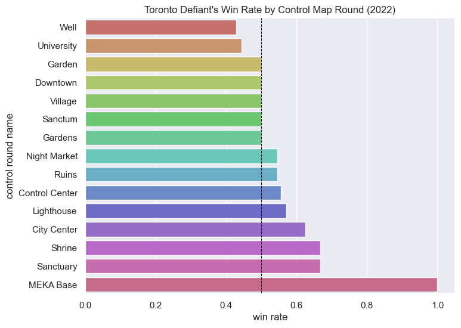

```python
# subset 2022
df_control_toronto_recent = df_control_toronto[df_control_toronto["year"] == 2022]

# create an empty list to store results
win_rates_toronto_recent = df_control_toronto_recent.groupby("control_round_name").apply(
    lambda x: (x["map_winner"] == "Toronto Defiant").sum() / len(x)
).reset_index(name="win_rate")

# sort values in DataFrame
win_rates_toronto_recent = win_rates_toronto_recent.sort_values(by = "win_rate", ascending = True)

# set plot dimensions
sns.set_theme(font_scale = 1)
plt.figure(figsize = (8, 6))

# creat barplot
sns.barplot(
    data = win_rates_toronto_recent, x = "win_rate", y = "control_round_name",
    dodge = False, orient = "y",
    hue = "control_round_name", palette = "hls", saturation = .7
)

# add graph and axes title
plt.title("Toronto Defiant's Win Rate by Control Map Round (2022)")
plt.xlabel("win rate")
plt.ylabel("control round name")

# add vertical line at 0.5
plt.axvline(x = 0.5, color = "black", linestyle = "--", linewidth = .8)
```

- 5b) **(5 marks)** Which plot should be used to make recommendations for Toronto in 2023? Based on this judgement and the plot you generated, what map should Toronto practice the most? Are there any problems with this analysis?

The plot for 2022 should be used to make recommendations for Toronto in 2023 as it will provide the most recent data on performance, highlighting current areas of strength and weakness. Furthermore, older data may not accurately reflect the strategies and dynamics of the current team members, affecting its application for future recommendations.

Based on this reasoning, Toronto should practice the Well control map since they performed poorly on that map in 2022. This round map had the lowest win rate at around 0.4.

One issue with the analysis is that the graph does not provide information on sample size. By looking at this graph, we cannot determine how many rounds were played on each map, making it difficult to determine the reliability of the win rates. For example, a low win rate on a given control map with few plays could be due to random variance as opposed to true weakness. Including sample sizes would provide better context and allow for more informed recommendations.

- 5c) **(2 marks)** Assign each team a rank according to their 2022 control map win rate, with 1 being the highest win rate on control maps in 2022 and 20 being the lowest win rate on control maps in 2022. Print each team name with its rank beside it.

```python
# subset 2022 control map data
df_control_2022 = df_control_maps[df_control_maps["year"] == 2022]

# calculate the number of wins for each team
team_wins_2022 = df_control_2022.groupby("map_winner").size().reset_index(name="wins")

# calculate total games played (winner and loser)
total_games_2022 = (
    pd.concat([df_control_2022["map_winner"], df_control_2022["map_loser"]])
    .value_counts()
    .reset_index(name="total_games")
)

# rename column in DataFrame
total_games_2022 = total_games_2022.rename(columns = {"index": "team"})
team_wins_2022 = team_wins_2022.rename(columns = {"map_winner": "team"})

# merge two DataFrames
team_stats_2022 = pd.merge(team_wins_2022, total_games_2022, left_on = "team", right_on= "team", how = "outer")

# calculate win rate
team_stats_2022["win_rate"] = team_stats_2022["wins"] / team_stats_2022["total_games"]

# assign rank based on win rate
team_stats_2022["rank"] = team_stats_2022["win_rate"].rank(ascending = False, method = "dense").astype(int)

# sort teams by rank
team_stats_2022_sorted = team_stats_2022.sort_values(by = "rank")

# Print sorted results
teams_2022 = list(team_stats_2022_sorted["team"])
ranks_2022 = list(team_stats_2022_sorted["rank"])

for i in range(len(teams_2022)):
    team = teams_2022[i]
    rank = ranks_2022[i]
    print(f"{rank}. {team}")
```

```
1. Houston Outlaws
2. Seoul Dynasty
3. Dallas Fuel
4. Los Angeles Gladiators
5. Atlanta Reign
6. London Spitfire
7. San Francisco Shock
8. Hangzhou Spark
9. Toronto Defiant
10. Shanghai Dragons
11. Florida Mayhem
12. Philadelphia Fusion
13. Los Angeles Valiant
14. Boston Uprising
15. Chengdu Hunters
16. Guangzhou Charge
16. Washington Justice
17. Vancouver Titans
18. New York Excelsior
19. Paris Eternal
```

- 5d) **(3 marks)** Determine Toronto's three best and three worst control map names (by win rate) in 2022. Print the mean rank of the teams Toronto played for each of these maps.

```python
# identify 3 best and 3 worst control map names
win_rates_toronto_2022_sorted = win_rates_toronto_recent.sort_values(by = "win_rate", ascending = True)

worst = list(win_rates_toronto_2022_sorted['control_round_name'][:3])
best = list(win_rates_toronto_2022_sorted['control_round_name'][-3:])

maps_of_interest = worst + best

print(f"3 worst control round maps: {worst}")
print(f"3 best control round maps: {best}")
print(maps_of_interest)
```

```
3 worst control round maps: ['Well', 'University', 'Garden']
3 best control round maps: ['Shrine', 'Sanctuary', 'MEKA Base']
['Well', 'University', 'Garden', 'Shrine', 'Sanctuary', 'MEKA Base']
```

```python
# calculate mean rank of teams Toronto played on each map

# create empty dictionary
mean_ranks = {}

# iterate through maps of interest
for map_name in maps_of_interest:

    # filter the DataFrame for the map of interest
    map_data = df_control_2022[df_control_2022["control_round_name"] == map_name]

    # list opponents whether Toronto was a winner/loser
    opponent = list(map_data.loc[map_data["map_winner"] == "Toronto Defiant", "map_loser"])
    opponent += list(map_data.loc[map_data["map_loser"] == "Toronto Defiant", "map_winner"])

    # calculate mean rank of opponents
    if len(opponent) > 0:

        # filter main DataFrame to get ranks
        opponent_ranks = team_stats_2022[team_stats_2022["team"].isin(opponent)]["rank"]

        # calculate mean rank
        mean_rank = opponent_ranks.mean()

    else:
        mean_rank = None

    mean_ranks[map_name] = mean_rank

for map_name, mean_rank in mean_ranks.items():
    category = "Worst" if map_name in worst else "Best"
    print(f"Mean rank of teams Toronto played on the {category} map '{map_name}: {mean_rank}")
```

```
Mean rank of teams Toronto played on the Worst map 'Well: 10.428571428571429
Mean rank of teams Toronto played on the Worst map 'University: 9.625
Mean rank of teams Toronto played on the Worst map 'Garden: 9.714285714285714
Mean rank of teams Toronto played on the Best map 'Shrine: 14.0
Mean rank of teams Toronto played on the Best map 'Sanctuary: 3.6666666666666665
Mean rank of teams Toronto played on the Best map 'MEKA Base: 1.0
```

- 5e) **(3 marks)** Compare the mean ranks on Toronto's best maps to their worst maps. What does this analysis reveal about Toronto's map-specific win rates?

# Question 6 -- (9 marks)

The league is considering changing the rules if too many matches (>5%) end in a draw. The league organizers consider draws to be bad for the game.

- 6a) **(3 marks)** What proportion of escort maps end in a draw?

```python
# calculate number of escort maps that ended in a draw
num_draws = (df_escort_maps["map_winner"] == "draw").sum()

# calculate the total number of escort maps
total_escort_maps = len(df_escort_maps)

# calculate the proportion of escort maps that ended in a draw
draw_proportion = num_draws / total_escort_maps

# print the result
print(f"Proportion of Escort maps that ended in a draw: {draw_proportion:.2%}")

# Check if the proportion exceeds 5%
if draw_proportion > 0.05:
    print("The proportion of draws is greater than 5%. The league might consider changing the rules.")
else:
    print("The proportion of draws is within acceptable limits.")
```

```
Proportion of Escort maps that ended in a draw: 3.84%
The proportion of draws is within acceptable limits.
```

- 6b) **(6 marks)** Make a bar plot of number of draws by map. Do certain escort maps have more draws? What proportion of draws happen on the maps with the two highest number of draws -- what would you tell the league organisers concerning this proportion?

[output not shown]

[figure not shown]

```python
# filter for draws
escort_draws = df_escort_maps[df_escort_maps["map_winner"] == "draw"]

# count number of draws for each map
draws_by_map = escort_draws["map_name"].value_counts()

# set figure size
plt.figure(figsize=(12, 6))

# create barplot
sns.barplot(
    x = draws_by_map.index,
    y=draws_by_map.values,
    hue = draws_by_map.index,
    palette="viridis")

# change graph and axes titles
plt.title("Number of Draws by Escort Map in 2022")
plt.xlabel("map name")
plt.ylabel("number of draws")
plt.xticks(rotation=45)
```

```python
# calculate the proportion of draws for the top 2 maps
top_2_maps = draws_by_map.head(2)
top_2_proportion = top_2_maps.sum() / draws_by_map.sum()

top_2_map_names = list(top_2_maps.index)

# print results
print(f"The top 2 maps with the highest number of draws are:{top_2_maps}")
print(f"Proportion of draws happening on these two maps: {top_2_proportion:.2%}")

# recommendation for the League Organizers
if top_2_proportion > 0.4:
    print("Recommendation: A significant proportion of draws (over 40%) occur on just two maps. "
          "Consider analyzing and adjusting the rules or layout for these specific maps to reduce the likelihood of draws.")
else:
    print("Recommendation: The distribution of draws is relatively balanced across maps. General rule changes may be more effective.")
```

```
The top 2 maps with the highest number of draws are:map_name
Volskaya Industries    98
Temple of Anubis       59
Name: count, dtype: int64
Proportion of draws happening on these two maps: 43.13%
Recommendation: A significant proportion of draws (over 40%) occur on just two maps. Consider analyzing and adjusting the rules or layout for these specific maps to reduce the likelihood of draws.
```

# Question 7 -- (8 marks)

On escort maps, the attacker must push a "payload" a certain distance within an alotted time. If the attacker pushes the payload to the end of the map before the alotted time is up, then the attacker can bank that time. On the other hand, if the attacker does not push the payload to the end of the map, the distance they were able to push it is recorded.

- 7a) **(4 marks)** On maps where the attacker won the round, print the summary statistics of the `attacker_time_banked` column, along with a histogram of the `attacker_time_banked` column. On maps where the attacker lost the round, print the summary statistics of the `attacker_payload_distance` column, along with a histogram of the `attacker_payload_distance` column.

```
Summary statistics for `attacker_time_banked` on maps where the attacker won the round:
count    4650.000000
mean      102.680841
std        94.727551
min         0.000000
25%         0.000000
50%        89.320032
75%       172.368532
max       404.037000
Name: attacker_time_banked, dtype: float64
```

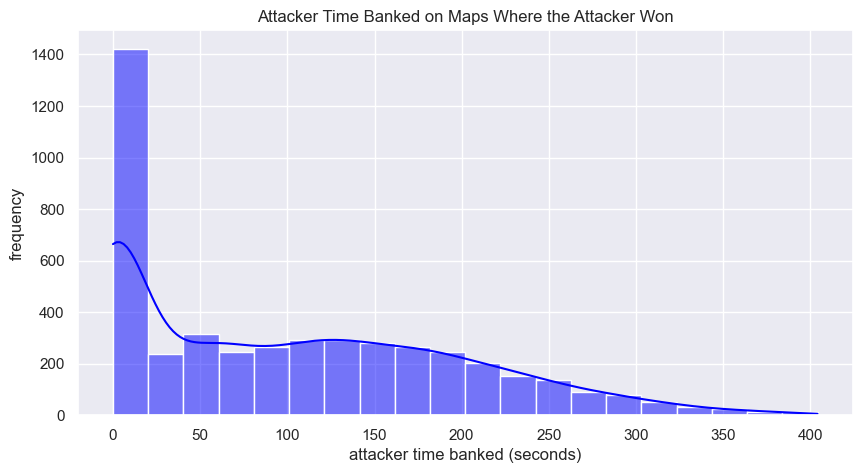

```python
# identify maps where attacker won
attacker_wins = df[(df["map_winner"] == df["Attacker"]) & (df["map_type"] == "escort")]

# identify maps where the attacker lost
attacker_losses = df[(df["map_winner"] != df["Attacker"]) & (df["map_type"] == "escort")]

# print summary statistics for `attacker_time_banked` when the attacker won
print("Summary statistics for `attacker_time_banked` on maps where the attacker won the round:")
print(attacker_wins["attacker_time_banked"].describe())

# set figure size
plt.figure(figsize=(10, 5))

# create histogram for attacker time banked on maps where the attacker won
sns.histplot(attacker_wins["attacker_time_banked"].dropna(), color = "blue", bins=20, kde=True)

# set graph and axes titles
plt.title("Attacker Time Banked on Maps Where the Attacker Won")
plt.xlabel("attacker time banked (seconds)")
plt.ylabel("frequency")
```

[output not shown]

- 7b) **(4 marks)** Describe the characteristics of the histrograms and interpret the summary statistics in the context of the data.

#### Histogram 1 Analyis

The histogram has a right-skewed distribution with many 0 values indicating that there were many cases where attackers won right as time ran out. This suggests that escort maps could be challenging to complete with a lot of time left. On average, attacker teams finished with around 102 seconds banked. And the most time an attacker team has banked was 404 seconds. There seems to be significant variation in how efficiently terams can complete maps.